# R Notebook

```r
#download.file("https://ibm.box.com/shared/static/5wah9atr5o1akuuavl2z9tkjzdinr1lv.csv",              destfile = "recipes.csv", quiet = TRUE)
# download.file("https://ibm.box.com/shared/static/rtqci87zjkgt7jpac9egrln9kifqqxuq.zip",
#               destfile = "/resources/rstudio/recipes-shiny.zip", quiet = TRUE)
# unzip("/resources/rstudio/recipes-shiny.zip")
## Install libraries if not installed
if("rpart" %in% rownames(installed.packages()) == FALSE) {install.packages("rpart",
    repo = "http://mirror.las.iastate.edu/CRAN/")}
if("rpart.plot" %in% rownames(installed.packages()) == FALSE) {install.packages("rpart.plot",
    repo = "http://mirror.las.iastate.edu/CRAN/")}
options(scipen = 999) #disable scientific notation
R.version.string
```

```
[1] "R version 3.3.2 (2016-10-31)"
```

# Intro

This is a sample based on an original version from IBM [Cognitive Builder Faire](https://cognitivebuilder.github.io/) in Seattle on March 26, 2017, by Polong Lin, Joseph Santarcangelo, Ph.D.

I redid it in RStudio for my own educational purposes.

First, load the data:

```r
recipes <- read.csv("recipes.csv")
grep("wasabi", names(recipes), value = TRUE) #Yes
```

```
[1] "wasabi"
```

Make a simple frequency table to understand a little about the data:

```r
t <- base::table(recipes$country) #frequency table
sort(t, decreasing = TRUE)[1:5]
```

```
American   Mexico  Italian    Italy    Asian
   40150     1754     1715     1461     1176
```

Next clean the data

```r
recipes$country <- tolower( as.character(recipes$country) )
recipes$country[recipes$country == "china"] <- "chinese"
recipes$country[recipes$country == "france"] <- "french"
recipes$country[recipes$country == "germany"] <- "german"
recipes$country[recipes$country == "india"] <- "indian"
recipes$country[recipes$country == "israel"] <- "jewish"
recipes$country[recipes$country == "italy"] <- "italian"
recipes$country[recipes$country == "japan"] <- "japanese"
recipes$country[recipes$country == "korea"] <- "korean"
recipes$country[recipes$country == "mexico"] <- "mexican"
recipes$country[recipes$country == "scandinavia"] <- "scandinavian"
recipes$country[recipes$country == "thailand"] <- "thai"
recipes$country[recipes$country == "vietnam"] <- "vietnamese"
```

*Problem: Some countries have very few recipes*

Remove data for countries with <50 recipes:

```r
t <- sort(base::table(recipes$country), decreasing = T)
filter_list <- names( t[ t >= 50 ] )
before <- nrow(recipes) #number of rows of original df
recipes <- recipes[recipes$country %in% filter_list, ]
after <- nrow(recipes)
print(paste(before - after, "rows removed."))
```

```
[1] "288 rows removed."
```

```r
sort(base::table(recipes$country), decreasing = T)
```

```
               american                 italian                 mexican
                  40150                    3250                    2390
                 french                   asian              east_asian
                   1264                    1193                     951
                 korean                  canada                  indian
                    799                     774                     598
                western                 chinese       southern_soulfood
                    450                     442                     346
                 jewish                japanese      spanish_portuguese
                    329                     320                     291
                 german           mediterranean                    thai
                    289                     289                     289
         uk-and-ireland            scandinavian           middleeastern
                    282                     250                     248
  central_southamerican          eastern-europe                   greek
                    241                     235                     225
       english_scottish               caribbean            cajun_creole
                    204                     183                     146
easterneuropean_russian                moroccan                 african
                    146                     137                     115
           southwestern           south-america              vietnamese
                    108                     103                      95
                  irish                   spain           north-african
                     86                      75                      60
               portugal
                     50
```

Convert all of the columns into factors (to run the classification model later)

```r
recipes[,names(recipes)] <- lapply(recipes[,names(recipes)] , as.factor)
```

## Q: Can we tell that some food is Japanese if it contains rice and soy sauce and wasabi and seaweed?

```r
head(recipes[recipes$rice == "Yes" &
        recipes$soy_sauce == "Yes" &
        recipes$wasabi == "Yes" &
        recipes$seaweed == "Yes",1:5])
```

|  | country | almond | angelica | anise | anise_seed |
| --- | --- | --- | --- | --- | --- |
| 11307 | japanese | No | No | No | No |
| 11322 | japanese | No | No | No | No |
| 11362 | japanese | No | No | No | No |
| 12172 | asian | No | No | No | No |
| 12386 | asian | No | No | No | No |
| 13011 | asian | No | No | No | No |

## Q: Which ingredients are most common? Which are the least-used ingredients?¶

Goals: * count the ingredients across all recipes

```r
## Sum the row count when the value of the row in a column is equal to "Yes" (value of 2)
ingred <- unlist(
            lapply( recipes[, names(recipes)], function(x) sum(as.integer(x) == 2))
            )
## Transpose the dataframe so that each row is an ingredient
ingred <- as.data.frame( t( as.data.frame(ingred) ))

ing_df <- data.frame("ingredient" = names(ingred),
                     "count" = as.numeric(ingred[1,])
                    )

ing_df_sort <- ing_df[order(ing_df$count, decreasing = TRUE),]
rownames(ing_df_sort) <- 1:nrow(ing_df_sort)
head(ing_df_sort)
```

|  | ingredient | count |
| --- | --- | --- |
| 1 | country | 40150 |
| 2 | egg | 21025 |
| 3 | wheat | 20781 |
| 4 | butter | 20719 |
| 5 | onion | 18080 |
| 6 | garlic | 17353 |

difference among countries

```r
by_country_norm <- aggregate(recipes,
                        by = list(recipes$country),
                        FUN = function(x) round(sum(as.integer(x) == 2)/
                                                length(as.integer(x)),4))
#Remove the unnecessary column "country"
by_country_norm <- by_country_norm[,-2]
#Rename the first column into "country"
names(by_country_norm)[1] <- "country"

head(by_country_norm[,1:5])
```

|  | country | almond | angelica | anise | anise_seed |
| --- | --- | --- | --- | --- | --- |
| 1 | african | 0.1565 | 0 | 0.0000 | 0.0000 |
| 2 | american | 0.0406 | 0 | 0.0030 | 0.0006 |
| 3 | asian | 0.0075 | 0 | 0.0008 | 0.0025 |
| 4 | cajun_creole | 0.0000 | 0 | 0.0000 | 0.0000 |
| 5 | canada | 0.0362 | 0 | 0.0000 | 0.0000 |
| 6 | caribbean | 0.0164 | 0 | 0.0109 | 0.0000 |

# Find specific ethnic foods

```r
region <- "canada" #try: italian
regiondata <- by_country_norm[by_country_norm$country == region,]
head(t(sort(regiondata, decreasing = TRUE)))
```

```
        5
country "canada"
wheat   "0.3953"
butter  "0.3811"
egg     "0.354"
onion   "0.3437"
garlic  "0.27"
```

top 5 most popular ingredients in each country

```r
for(nation in by_country_norm$country[1:7]){
    x <- sort(by_country_norm[by_country_norm$country == nation,], decreasing = TRUE)
    cat(c(toupper(nation)))
    cat("\n")
    cat(paste0(names(x)[2:6], " (", round(x[2:6]*100,0), "%) "))
    cat("\n")
    cat("\n")
}
```

```
AFRICAN
onion (53%)  olive_oil (52%)  garlic (50%)  cumin (43%)  cayenne (36%)

AMERICAN
butter (41%)  egg (41%)  wheat (40%)  onion (29%)  milk (27%)

ASIAN
soy_sauce (50%)  ginger (49%)  garlic (48%)  rice (41%)  scallion (38%)

CAJUN_CREOLE
onion (70%)  cayenne (56%)  garlic (49%)  butter (36%)  bell_pepper (34%)

CANADA
wheat (40%)  butter (38%)  egg (35%)  onion (34%)  garlic (27%)

CARIBBEAN
onion (51%)  garlic (51%)  black_pepper (31%)  vegetable_oil (31%)  tomato (30%)

CENTRAL_SOUTHAMERICAN
garlic (57%)  onion (54%)  cayenne (52%)  tomato (41%)  corn (33%)
```

k-means clustering

```r
n_cluster = 5
df_cluster <- by_country_norm
k <- kmeans(df_cluster[,-1], n_cluster)
df_cluster$cluster <- k$cluster
for(i in seq( 1, n_cluster )){
    i <- as.character(i)
    cat(paste0("[Cluster ", i, "]----------------------------------------------------------"))
    cat("\n")

    print(paste0(as.character(df_cluster[df_cluster$cluster == i,]$country)))
    cat("\n")
    }
```

```
[Cluster 1]----------------------------------------------------------
[1] "thai"       "vietnamese"

[Cluster 2]----------------------------------------------------------
 [1] "american"                "canada"                  "eastern-europe"
 [4] "easterneuropean_russian" "english_scottish"        "french"
 [7] "german"                  "irish"                   "jewish"
[10] "scandinavian"            "southern_soulfood"       "uk-and-ireland"
[13] "western"

[Cluster 3]----------------------------------------------------------
[1] "east_asian" "korean"

[Cluster 4]----------------------------------------------------------
[1] "asian"    "chinese"  "japanese"

[Cluster 5]----------------------------------------------------------
 [1] "african"               "cajun_creole"          "caribbean"
 [4] "central_southamerican" "greek"                 "indian"
 [7] "italian"               "mediterranean"         "mexican"
[10] "middleeastern"         "moroccan"              "north-african"
[13] "portugal"              "south-america"         "southwestern"
[16] "spain"                 "spanish_portuguese"
```

# Decision Trees

```r
# Run this
## Install libraries if not installed
if("rpart" %in% rownames(installed.packages()) == FALSE) {install.packages("rpart",
    repo = "http://mirror.las.iastate.edu/CRAN/")}
if("rpart.plot" %in% rownames(installed.packages()) == FALSE) {install.packages("rpart.plot",
    repo = "http://mirror.las.iastate.edu/CRAN/")}
## Load libraries
library(rpart)
library(rpart.plot)
```

```r
#Choose one:
head(recipes[,1:5])
```

|  | country | almond | angelica | anise | anise_seed |
| --- | --- | --- | --- | --- | --- |
| 1 | vietnamese | No | No | No | No |
| 2 | vietnamese | No | No | No | No |
| 3 | vietnamese | No | No | No | No |
| 4 | vietnamese | No | No | No | No |
| 5 | vietnamese | No | No | No | No |
| 6 | vietnamese | No | No | No | No |

```r
#str(recipes)
#table(recipes$country)
```

But American data dominiates so much, that we can’t do good decision trees.

```r
## Select subset of countries
bamboo_tree <- rpart(formula = country ~ .,
                     data = recipes[recipes$country %in% c("korean",
                                                           "japanese",
                                                           "chinese",
                                                           "thai",
                                                           "indian"),],
                     method ="class")
```

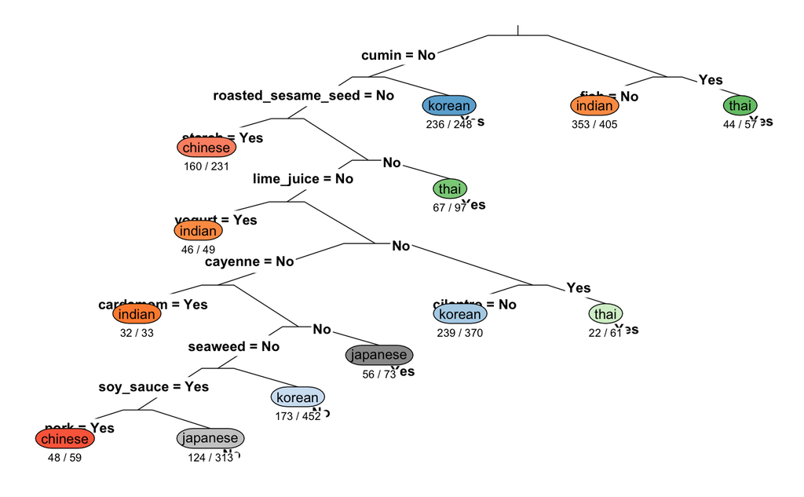

```r
# Run this
## Plot the East Asian + Indian model
## run "?rpart.plot" if you want to see the arguments for rpart.plot
rpart.plot(bamboo_tree, type = 3, fallen.leaves = F, extra = 2, under = TRUE, cex = 0.75, varlen = 0, faclen = 0)
```

more summaries

```r
names(bamboo_tree)
```

```
 [1] "frame"               "where"               "call"                "terms"
 [5] "cptable"             "method"              "parms"               "control"
 [9] "functions"           "numresp"             "splits"              "csplit"
[13] "variable.importance" "y"                   "ordered"
```

more

```r
bamboo <- recipes[recipes$country %in% c("korean", "japanese", "chinese",
                                              "thai", "indian"),]
table(as.factor(as.character(bamboo$country)))
```

```
 chinese   indian japanese   korean     thai
     442      598      320      799      289
```

```r
sample_n <- 100
## Take n recipes from each country
set.seed(4) #Set random seed
korean <- bamboo[sample(which(bamboo$country == "korean") , sample_n), ]
japanese <- bamboo[sample(which(bamboo$country == "japanese") , sample_n), ]
chinese <- bamboo[sample(which(bamboo$country == "chinese") , sample_n), ]
thai <- bamboo[sample(which(bamboo$country == "thai") , sample_n), ]
indian <- bamboo[sample(which(bamboo$country == "indian") , sample_n), ]
#Create the dataframe
bamboo_test <- rbind(korean,japanese, chinese, thai, indian)
bamboo_train <- bamboo[!(rownames(bamboo) %in% rownames(bamboo_test)),]
## Check that we have 100 recipes from each cuisine
table(as.factor(as.character(bamboo_test$country)))
```

```
 chinese   indian japanese   korean     thai
     100      100      100      100      100
```

```r
## Check that we have subtracted 100 recipes from each cuisine
table(as.factor(as.character(bamboo_train$country)))
```

```
 chinese   indian japanese   korean     thai
     342      498      220      699      189
```

```r
#Train on the bamboo_train data
bamboo_tree_pred <- rpart(formula = country ~ .,
                     data = bamboo_train[bamboo_train$country %in% c("korean",
                                                           "japanese",
                                                           "chinese",
                                                           "thai",
                                                           "indian"),],
                     method ="class")
```

plot it

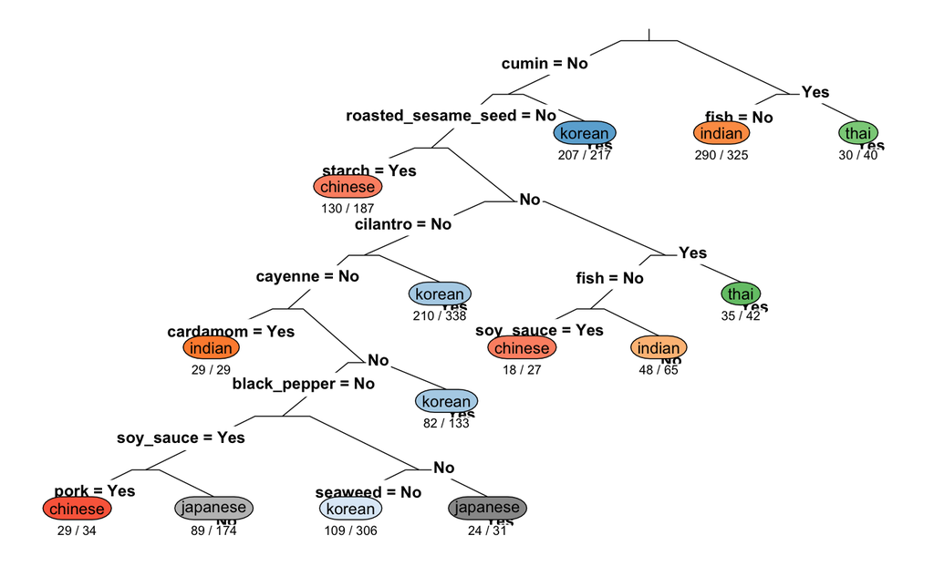

```r
#Plot the trained tree
rpart.plot(bamboo_tree_pred, type = 3, extra = 2, fallen.leaves = F, under = TRUE,
           cex = 0.75, varlen = 0, faclen = 0)
```